# SM_01_ARCHAE_NUM_CONTR

Archeological artifacts - number of contributions or items contributed · Number report

## Overview

**Description**

Number of contributions

**Table**

`SM-P01-T00-NONCASH-CONTRIBUTIONS` (one)

**Location code**

`SCHED-M-PART-01-LINE-24-COL-B`

**Family**

`SCHED-M-PART-01-LINE-24-COL-B`

**Data type**

numeric (xsd: IntegerNNType, )

**Scope**

PC

**Status**

unreviewed

3

xpaths mapped (2 observed)

349

filings with a value

2009–2024

tax years observed

1

open flags (0 errors)

## Flags

| Severity | Flag | Xpath | Detail |
| --- | --- | --- | --- |
| ⓘ info | `UNOBSERVED` | IRS990ScheduleM/Form990ScheduleMPartI/ArchaeologicalArtifacts/NumberOfContributions | never observed in TY2009-2024 filings |

## Xpaths

All mapped xpaths (under /Return/ReturnData or /Return/ReturnHeader), oldest first. Charts label each series by its xpath.

| Xpath | Form | Chart label | First year | Last year | Versions | Filings | Repeats in |
| --- | --- | --- | --- | --- | --- | --- | --- |
| IRS990ScheduleM/ArchaeologicalArtifacts/NumberOfContributions | Sched M | …90ScheduleM/ArchaeologicalArtifacts/NumberOfContributions | 2009 | 2012 | 11 | 82 | 0.0% |
| IRS990ScheduleM/ArchaeologicalArtifactsGrp/ContributionCnt | Sched M | same | 2013 | 2024 | 33 | 267 | 0.0% |
| IRS990ScheduleM/Form990ScheduleMPartI/ArchaeologicalArtifacts/NumberOfContributions | Sched M | …eduleMPartI/ArchaeologicalArtifacts/NumberOfContributions |  |  |  | 0 |  |

## Coverage

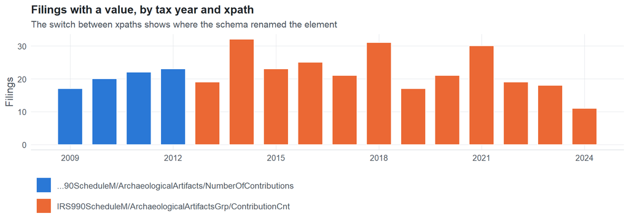

**Table view**

Table view: filings by tax year and series

| Tax year | …90ScheduleM/ArchaeologicalArtifacts/NumberOfContributions | IRS990ScheduleM/ArchaeologicalArtifactsGrp/ContributionCnt |
| --- | --- | --- |
| 2009 | 17 | 0 |
| 2010 | 20 | 0 |
| 2011 | 22 | 0 |
| 2012 | 23 | 0 |
| 2013 | 0 | 19 |
| 2014 | 0 | 32 |
| 2015 | 0 | 23 |
| 2016 | 0 | 25 |
| 2017 | 0 | 21 |
| 2018 | 0 | 31 |
| 2019 | 0 | 17 |
| 2020 | 0 | 21 |
| 2021 | 0 | 30 |
| 2022 | 0 | 19 |
| 2023 | 0 | 18 |
| 2024 | 0 | 11 |

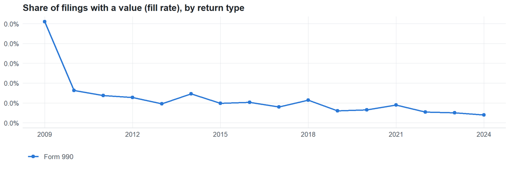

**Table view**

Table view: fill rate

| Tax year | Return type | Filings | All filings | Fill rate |
| --- | --- | --- | --- | --- |
| 2009 | Form 990 | 17 | 33,311 | 0.05% |
| 2010 | Form 990 | 20 | 123,025 | 0.02% |
| 2011 | Form 990 | 22 | 159,504 | 0.01% |
| 2012 | Form 990 | 23 | 179,688 | 0.01% |
| 2013 | Form 990 | 19 | 198,855 | 0.01% |
| 2014 | Form 990 | 32 | 218,619 | 0.01% |
| 2015 | Form 990 | 23 | 233,519 | 0.01% |
| 2016 | Form 990 | 25 | 243,903 | 0.01% |
| 2017 | Form 990 | 21 | 261,612 | 0.01% |
| 2018 | Form 990 | 31 | 271,442 | 0.01% |
| 2019 | Form 990 | 17 | 283,694 | 0.01% |
| 2020 | Form 990 | 21 | 320,342 | 0.01% |
| 2021 | Form 990 | 30 | 336,480 | 0.01% |
| 2022 | Form 990 | 19 | 349,055 | 0.01% |
| 2023 | Form 990 | 18 | 354,768 | 0.01% |
| 2024 | Form 990 | 11 | 277,298 | 0.00% |

## Values

| Result | Check | Detail |
| --- | --- | --- |
| ✓ pass | Values parse as numbers | 100.0% of values are numeric |
| ✓ pass | Pooled xpaths are on the same scale (same return type) | largest ratio of medians between xpaths: 1.0x |
| ⚠ fail | One scale across xpaths (fraction vs percent) | …90ScheduleM/ArchaeologicalArtifacts/NumberOfContributions: percent or small count; IRS990ScheduleM/ArchaeologicalArtifactsGrp/ContributionCnt: large count or amount |

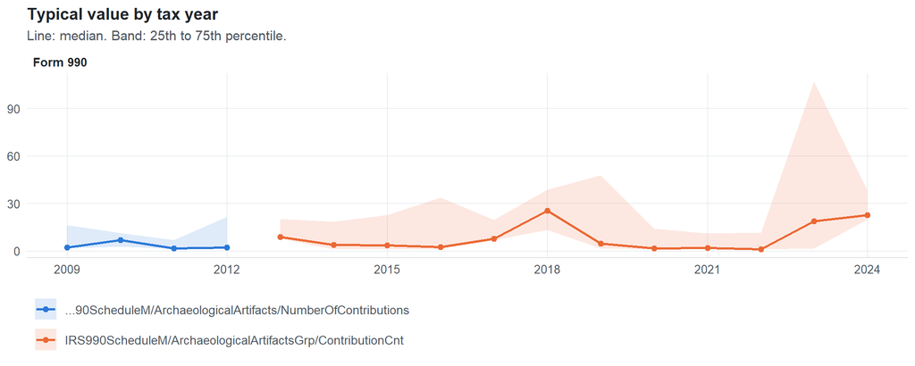

**Table view**

Table view: quartiles by tax year

| Series | Return | Tax year | Filings | P25 | Median | P75 |
| --- | --- | --- | --- | --- | --- | --- |
| …90ScheduleM/ArchaeologicalArtifacts/NumberOfContributions | 990 | 2009 | 17 | 1.59 | 2.24 | 16.26 |
| …90ScheduleM/ArchaeologicalArtifacts/NumberOfContributions | 990 | 2010 | 20 | 2.65 | 6.85 | 11.20 |
| …90ScheduleM/ArchaeologicalArtifacts/NumberOfContributions | 990 | 2011 | 22 | 1.25 | 1.50 | 6.75 |
| …90ScheduleM/ArchaeologicalArtifacts/NumberOfContributions | 990 | 2012 | 23 | 1.13 | 2.09 | 21.39 |
| IRS990ScheduleM/ArchaeologicalArtifactsGrp/ContributionCnt | 990 | 2013 | 19 | 7.74 | 8.68 | 20.24 |
| IRS990ScheduleM/ArchaeologicalArtifactsGrp/ContributionCnt | 990 | 2014 | 32 | 1 | 3.94 | 18.41 |
| IRS990ScheduleM/ArchaeologicalArtifactsGrp/ContributionCnt | 990 | 2015 | 23 | 1 | 3.61 | 22.67 |
| IRS990ScheduleM/ArchaeologicalArtifactsGrp/ContributionCnt | 990 | 2016 | 25 | 1.20 | 2.40 | 33.60 |
| IRS990ScheduleM/ArchaeologicalArtifactsGrp/ContributionCnt | 990 | 2017 | 21 | 6.83 | 7.71 | 19.62 |
| IRS990ScheduleM/ArchaeologicalArtifactsGrp/ContributionCnt | 990 | 2018 | 31 | 13.10 | 25.42 | 38.55 |
| IRS990ScheduleM/ArchaeologicalArtifactsGrp/ContributionCnt | 990 | 2019 | 17 | 1.62 | 4.65 | 47.88 |
| IRS990ScheduleM/ArchaeologicalArtifactsGrp/ContributionCnt | 990 | 2020 | 21 | 1 | 1.62 | 14.12 |
| IRS990ScheduleM/ArchaeologicalArtifactsGrp/ContributionCnt | 990 | 2021 | 30 | 1 | 1.77 | 11.13 |
| IRS990ScheduleM/ArchaeologicalArtifactsGrp/ContributionCnt | 990 | 2022 | 19 | 1 | 1 | 11.50 |
| IRS990ScheduleM/ArchaeologicalArtifactsGrp/ContributionCnt | 990 | 2023 | 18 | 1.50 | 18.67 | 107 |
| IRS990ScheduleM/ArchaeologicalArtifactsGrp/ContributionCnt | 990 | 2024 | 11 | 19.77 | 22.64 | 38.05 |

Summary by xpath and return type (all years)

| Series | Return | Filings | % numeric | % zero | % negative | Median (typical year) | P99 (typical year) |
| --- | --- | --- | --- | --- | --- | --- | --- |
| …90ScheduleM/ArchaeologicalArtifacts/NumberOfContributions | 990 | 82 | 100 | 1.22 | 0 | 2 | 54 |
| IRS990ScheduleM/ArchaeologicalArtifactsGrp/ContributionCnt | 990 | 267 | 100 | 4.49 | 0 | 2 | 182 |

Scale of each xpath

| Series | P99 (typical year) | Implied scale |
| --- | --- | --- |
| …90ScheduleM/ArchaeologicalArtifacts/NumberOfContributions | 54 | percent or small count |
| IRS990ScheduleM/ArchaeologicalArtifactsGrp/ContributionCnt | 182 | large count or amount |

## Examples

| Tax year | Return | Xpath | Organization | Value | Source |
| --- | --- | --- | --- | --- | --- |
| 2024 | 990 | IRS990ScheduleM/ArchaeologicalArtifactsGrp/ContributionCnt | INTOUCH OUTREACH RESOURCE CTR | 0 | [XML](https://gt990datalake-rawdata.s3.amazonaws.com/EfileData/XmlFiles/202620749349300227_public.xml) |
| 2023 | 990 | IRS990ScheduleM/ArchaeologicalArtifactsGrp/ContributionCnt | OVERLAKE MEDICAL CENTER & CLINICS | 1 | [XML](https://gt990datalake-rawdata.s3.amazonaws.com/EfileData/XmlFiles/202501269349301685_public.xml) |
| 2022 | 990 | IRS990ScheduleM/ArchaeologicalArtifactsGrp/ContributionCnt | MILWAUKEE PUBLIC MUSEUM INC | 13 | [XML](https://gt990datalake-rawdata.s3.amazonaws.com/EfileData/XmlFiles/202440969349301624_public.xml) |
| 2021 | 990 | IRS990ScheduleM/ArchaeologicalArtifactsGrp/ContributionCnt | Hicksville Gregory Museum | 4 | [XML](https://gt990datalake-rawdata.s3.amazonaws.com/EfileData/XmlFiles/202213149349305031_public.xml) |
| 2020 | 990 | IRS990ScheduleM/ArchaeologicalArtifactsGrp/ContributionCnt | HUMANE SOCIETY OF FAIRFAX COUNTY INC | 0 | [XML](https://gt990datalake-rawdata.s3.amazonaws.com/EfileData/XmlFiles/202123199349317812_public.xml) |
| 2019 | 990 | IRS990ScheduleM/ArchaeologicalArtifactsGrp/ContributionCnt | California Hospital Medical Center Foundation | 2 | [XML](https://gt990datalake-rawdata.s3.amazonaws.com/EfileData/XmlFiles/202121259349302027_public.xml) |
| 2018 | 990 | IRS990ScheduleM/ArchaeologicalArtifactsGrp/ContributionCnt | CHICKASAW INKANA FOUNDATION | 1 | [XML](https://gt990datalake-rawdata.s3.amazonaws.com/EfileData/XmlFiles/201911349349308866_public.xml) |
| 2017 | 990 | IRS990ScheduleM/ArchaeologicalArtifactsGrp/ContributionCnt | CLINTON COUNTY HISTORICAL ASSOC | 1 | [XML](https://gt990datalake-rawdata.s3.amazonaws.com/EfileData/XmlFiles/201803039349301830_public.xml) |
| 2016 | 990 | IRS990ScheduleM/ArchaeologicalArtifactsGrp/ContributionCnt | FIELD MUSEUM OF NATURAL HISTORY | 13 | [XML](https://gt990datalake-rawdata.s3.amazonaws.com/EfileData/XmlFiles/201703109349301330_public.xml) |
| 2015 | 990 | IRS990ScheduleM/ArchaeologicalArtifactsGrp/ContributionCnt | Milwaukee Public Museum Inc | 94 | [XML](https://gt990datalake-rawdata.s3.amazonaws.com/EfileData/XmlFiles/201741049349301454_public.xml) |
| 2014 | 990 | IRS990ScheduleM/ArchaeologicalArtifactsGrp/ContributionCnt | PEORIA RIVERFRONT MUSEUM | 600 | [XML](https://gt990datalake-rawdata.s3.amazonaws.com/EfileData/XmlFiles/201543169349305459_public.xml) |
| 2013 | 990 | IRS990ScheduleM/ArchaeologicalArtifactsGrp/ContributionCnt | CARTHAGE COLLEGE | 1 | [XML](https://gt990datalake-rawdata.s3.amazonaws.com/EfileData/XmlFiles/201520769349300712_public.xml) |

## Reviewer checklist

- The definition matches the form line and instructions for every xpath’s schema years.
- Every xpath pooled here measures the same thing on the 990 and 990-EZ (close enough for analysis).
- The coverage chart has no unexplained gaps or jumps between tax years.
- Each open flag is fixed, or accepted with a note in validation_log.csv.
- Counts are whole numbers and plausible (e.g. employees, volunteers, voting members).
- Ratios and percentages use one scale (0-1 or 0-100) across all xpaths and years.
- Units match the form line (hours per week, number of states, percent of support).

Record the review as a row in `inst/extdata/src/validation_log.csv` (variable_name, reviewer, date, status, note). Evidence built 2026-09-23 17:09:04 MST from the ef2 DuckDB builds (tax years 2009–2024).